# 1 Introduction

## B.2 NAT Port Mapping

NAT port mapping allows a client machine on the LAN (or home network) to appear on a specific port of the router’s public WAN IP address. This API (and NAT in general) is only used when the NDK is acting as an IP router, and when the IP network on one side of the router is using virtual IP addresses.

The functions described in this section illustrates how to install and remove port mappings. The functional operation of NAT and NAT Port Mapping is discussed in more detail in Section B.1.

### B.2.1 Function Overview

The following functions create and destroy port mappings:

| Function | Description |
| --- | --- |
| NatNew() | Create a new NAT entry (for port mapping) |
| NatFree() | Free a NAT entry |
| NatGetPNI() | Get a pointer to a NAT entry’s NATINFO structure |

### B.2.2 NAT Entry Information Structure

A port mapping is just a NAT entry. Each NAT entry has its own information structure. This NATINFO structure allows you to examine the status of a particular entry.

The specification of the NATINFO structure is as follows:

```c
typedef struct _natinfo {
        uint32_t TcpState;          // Current TCP State (Simplified)
#define NI_TCP_CLOSED  0            // Closed or closing
#define NI_TCP_SYNSENT 1            // Connecting
#define NI_TCP_ESTAB   2            // Established
        uint32_t      IPLocal;      // Translated IP Address
        uint16_t      PortLocal;    // Translated TCP/UDP Port
        uint32_t      IPForeign;    // IP Address of Foreign Peer
        uint16_t      PortForeign;  // Port of Foreign Peer
        unsigned char Protocol;     // IP Protocol
        uint16_t      PortMapped;   // Locally Mapped TCP/UDP Port (router)
        void          *hProxyEntry; // Handle to Proxy Entry (if any)
        uint32_t      Timeout;      // Expiration time in SECONDS
        void          *pUserData;   // Pointer to proxy callback data
} NATINFO;
```

The individual fields are defined as follows:

The NAT information structure is of little importance when only port mapping is required. It is mostly for use in NAT proxy filters.

### B.2.3 NAT API Functions

#### NatNew – Create a NAT Entry (for Port Mapping)

```c
void *NatNew( uint32_t      IPLocal,
              uint16_t      PortLocal,
              uint32_t      IPForeign,
              uint16_t      PortForeign,
              unsigned char Protocol,
              uint16_t      PortMapped,
              uint32_t      Timeout );
```

**Parameters**

- IPLocal: IP address (in network format) of host on the LAN to map
- PortLocal: TCP/UDP port value of host on the LAN to map
- IPForeign: IP address of WAN peer (usually NULL/wild for port mappings)
- PortForeign: TCP/UDP port of WAN peer (usually NULL/wild)
- Protocol: IP protocol (IPPROTO_TCP or IPPROTO_UDP)
- PortMapped: Port on router’s public WAN to map (usually a well-known port)
- Timeout: Timeout of entry in seconds (NULL for STATIC)

**Return Value** Handle to NAT entry, or NULL on error.

**Description** This function creates a NAT entry with the parameters as specified.

For example, to allow a host on a virtual IP address of 1.2.3.4 to run a Telnet server reachable via the router’s public (physical) IP address, a mapping would be installed to map TCP port 23 (telnet) to 1.2.3.4:23. If the connection were to be open to all foreign hosts, then *IPForeign* and *PortForeign* would be left NULL. The value of *Timeout* would also be NULL to make the entry STATIC.

```c
hNatTelnet = NatNew( htonl(0x01020304), 23, 0, 0, IPPROTO_TCP, 23, 0 );
```

The function returns a handle to the NAT entry created. This handle should be freed with *NatFree()* when the mapping is no longer desired.

#### NatFree – Destroy a NAT Entry

```c
void NatFree( void *hNat );
```

**Parameters**

- hNat: Handle to NAT entry created with *NatNew()*

**Return Value** None.

**Description** This function frees the supplied NAT entry. It is called to remove a STATIC NAT entry that is no longer required.

#### NatGetPNI – Get a Pointer to a NAT Entry’s NATINFO Structure

```c
NATINFO NatGetPNI( void *hNat );
```

**Parameters**

- hNat: Handle to NAT entry created with *NatNew()*

**Return Value** Pointer to NATINFO structure or NULL on error.

**Description** This function returns a pointer to the NATINFO structure defined in Section B.2.2. It is used mainly by NAT proxy filter callback functions.

## B.3 NAT Proxy Filters

NAT proxy filters allow NAT to operate correctly with network protocols that have addressing specific data in their packet payload data. This API (and NAT in general) is only used when the NDK is acting as an IP router, and when the IP network on one side of the router is using virtual IP addresses.

### B.3.1 Function Overview

The following functions create and destroy proxy filters:

| Function | Description |
| --- | --- |
| ProxyNew() | Create Proxy Filter for NAT entries |
| ProxyFree() | Destroy a Proxy Filter declaration |

The following function can be called from within a proxy filter callback function:

| Function | Description |
| --- | --- |
| ProxyPacketMod() | Modify a packet being processed by NAT |

### B.3.2 NAT Proxy Filter Callback Functions

The proxy filter callback functions allow the proxy programmer to examine NAT entry properties as the entries are created, plus the examination of packet data as packets pass between the LAN and WAN. This section describes the syntax of the callback functions that are supplied to the proxy filter when it is first installed in the system.

#### ProxyEnableCallback – Proxy Enable Callback Function

```c
int SampleProxyEnableCallback( NATINFO  *pNI,
                               uint32_t EnableFlag );
```

**Parameters**

- pNI: Pointer to NATINFO structure of NAT entry created
- EnableFlag: Set to 1 for an enable request

**Return Value** 1 to allow normal operation, or NULL to abort new NAT entry.

**Description** This function is called when a NAT entry containing a proxy is created or destroyed. When the entry is created, the value of *EnableFlag* is 1. When the entry is being destroyed, the value of *EnableFlag* is zero.

When *EnableFlag* is set, the return value of this function determines if the NAT entry will be enabled. If this function returns NULL, the NAT entry is immediately destroyed (in this event, the callback is not called a second time for this destroy). This can be used to restrict peer connections.

#### ProxyTx/RxCallback – Proxy Tx/Rx Callback Functions

```c
int SampleProxyTxCallback( NATINFO *pNI,
                           IPHDR   *pIpHdr );

int SampleProxyRxCallback( NATINFO *pNI,
                           IPHDR   *pIpHdr );
```

**Parameters**

- pNI: Pointer to NATINFO structure of NAT entry in use
- pIpHdr: Pointer to the IP header of the packet being translated

**Return Value** 1 to allow normal operation, or NULL to abort the supplied packet.

**Description** This function is called when a packet is crossing the router from the WAN to the LAN (Rx callback) or from the LAN to the WAN (Tx callback). The NAT entry containing a proxy that matches the packet is described by the supplied NATINFO structure. This structure was described in Section B.2.2.

The purpose of the callback is to examine the packet and take appropriate action based on its contents. The packet payload can be easily modified by the *ProxyPacketMod()* function described later in this section. The translation of the IP address and port information cannot be altered by this callback; however, the callback can act as a packet filter and discard unwanted packets by returning a value of NULL.

### B.3.3 NAT Proxy API Functions

#### ProxyNew – Create a New Proxy Filter for NAT Entries

```c
void *ProxyNew( uint32_t      NatMode,
                unsigned char Protocol,
                uint16_t      Port,
                uint32_t      IPTarget,
                int (*pfnEnableCb)(NATINFO *, uint),
                int (*pfnTxCb)(NATINFO *, IPHDR *),
                int (*pfnRxCb)(NATINFO *, IPHDR *) );
```

**Parameters**

- NatMode: Port direction to detect (NAT_MODE_RX or NAT_MODE_TX)
- Protocol: Protocol to use (IPPROTO_TCP or IPPROTO_UDP)
- Port: Port value for RX or TX packets to detect
- IPTarget: New IP destination NAT_MODE_RX proxy
- pfnEnableCb: Pointer to proxy *Enable* callback function (NULL if none)
- pfnTxCb: Pointer to proxy Tx callback function (NULL if none)
- pfnRxCb: Pointer to proxy Rx callback function (NULL if none)

**Return Value** Handle to new proxy, or NULL on error.

**Description** This function creates a hook that is examined whenever a new NAT entry is created.

The calling parameter *NatMode* specifies the direction of the proxy (NAT_MODE_RX for servers behind the firewall, and NAT_MODE_TX for clients behind the firewall).

The *Protocol* and *Port* values are the IP protocol and well-known port of the protocol to proxy.

For example, if setting up a FTP client proxy, set:

```c
NatMode = NAT_MODE_TX
Protocol = IPPROTO_TCP
Port = 21
```

*IPTarget* is used only in server proxies (when *NatMode* is set to NAT_MODE_RX). This specifies the machine behind the firewall that is actually providing the service.

The three pointers to callback functions correspond to the proxy filter callback functions described in the previous section.

The function returns a handle to the new proxy. Note that a proxy handle is not the same as (or compatible with) a NAT entry handle.

The proxy should be destroyed by calling *ProxyFree()* when it is no longer needed.

#### ProxyFree – Destroy a Proxy Filter Declaration

```c
void ProxyFree( void *hProxy );
```

**Parameters**

- hProxy: Handle to Proxy Filter entry created with *ProxyNew()*

**Return Value** None.

**Description** This function frees the supplied Proxy Filter entry. It is called to remove an entry that is no longer required.

#### ProxyPacketMod – Modify the Contents of a Packet

```c
IPHDR *ProxyPacketMod( uint32_t      Offset,
                       uint32_t      OldSize,
                       uint32_t      NewSize,
                       unsigned char *pNewData );
```

**Parameters**

- Offset: Offset in bytes from start of IP header to first modified byte
- OldSize: Size of old data at *Offset*
- NewSize: Size of new data to replace old data at *Offset*
- pNewData: Pointer to new data to replace old data

**Return Value** Pointer to new IP header of packet. This pointer is used for further modifications (if needed).

**Description** This function may only be called from a proxy filter callback function. Its purpose is to modify the contents of a TCP or UDP packet, and perform the necessary adjustments for packet size - including TCP sequencing adjustment.

# C Point-to-Point Protocol

Point to point protocol (PPP) was originally designed as a replacement for SLIP (serial line IP) in sending IP packets via a serial line. In addition to its massive popularity in performing this function, PPP has also been increasingly used for the transmission of packets over other media. This is due to PPP’s inherent peer-to-peer nature, allowing for per-connection security and billing.

The NDK has built-in support for both PPP servers and clients. The PPP support API is designed to be shared by one or more physical devices. One obvious device that can be hooked to PPP is a serial line, but the stack also contains support for PPP over Ethernet (PPPoE). The low level PPP API as well as Serial HDLC and PPPoE are all discussed in this appendix.

## C.1 Low Level PPP Support

This section describes the operation of the PPP support API included in the NDK.

> **NOTE:** Unlike the HDLC and PPPoE APIs that are application callable, the low level PPP support API is designed to be called from the kernel layer only. You should be thoroughly familiar with the operation of the kernel and the *llEnter()*/*llExit()* functions before attempting to use the APIs described in this section.

### C.1.1 PPP Operation

PPP is very much like Ethernet in that there is a defined packet format. The basic PPP packet is shown below. It consists of flag delimiters, address and control bytes, protocol field (similar to ether-type under Ethernet), and a two byte checksum.

*Figure C-1 Standard PPP Frame Over Serial Line*

| Flag (7E) | Addr (FF) | Control (03) | Protocol | Payload | CRC | Flag (7E) |
| --- | --- | --- | --- | --- | --- | --- |
| 1 | 1 | 1 | 2 | 1500 | 2 | 1 |

To abstract out the actual processing of the PPP data from the processing of the PPP frame encoding, the PPP support included in the NDK expects a smaller frame, consisting of the protocol and payload fields only. This format is shown in Figure C-2.

*Figure C-2 PPP Frame Processed by PPP API*

| Protocol | Payload |
| --- | --- |
| 2 | Size specified by layer 2 (about 1500) |

The abstraction of PPP from the layer 2 encoding allows PPP to be carried by a variety of physical devices. The programming interface to the PPP layer called by the application is actually exposed by the layer 2 encoder. This layer 2 encoder is referred to as a serial interface (SI), but does not have to be a serial port. This interoperation between PPP and the SI is shown in Figure C-3. The functions shown in the dotted rectangle are those provided by the serial interface software.

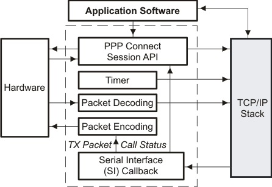

As shown in Figure C-3, the SI interface has the responsibility of providing for connection control, a timer used by PPP for timeout, packet encoding and decoding, and a SI callback function for status messages and packet transmission. Note that the SI driver developer also defines the actual API used by the application software to establish and tear down PPP connection sessions. There is no specific requirements in specifying the session API for any particular PPP device, but the APIs defined for HDLC and PPPoE can be used as a guide.

### C.1.2 Function Overview

The SI interface module is charged with communicating with both the hardware and the application program, but the PPP packets themselves are processed via the PPP support functions in the stack. The PPP support software provides the following functions for use by the SI module:

| Function | Description |
| --- | --- |
| `pppNew()` | Create a new PPP connection instance |
| `pppFree()` | Destroy an existing PPP connection instance |
| `pppTimer()` | Inform PPP that a 1 second timer tick has expired |
| `pppInput()` | Pass in a received PPP packet for processing |

The formal declaration of these functions appear later in this section (see Section C.1.6).

> **NOTE:** These functions can only be called in kernel mode. See Appendix A for programming in kernel mode.

### C.1.3 Supported Protocols

In keeping with trying to maintain a small footprint, the PPP software supports a subset of the general PPP protocols. The following are supported:

- Link Control Protocol (LCP)
- Internet Protocol Control Protocol (IPCP)
- Password Authentication Protocol (PAP)
- Challenge Handshake Authentication Protocol (CHAP) using MD5
- Internet Protocol (IP)

### C.1.4 SI Module Callback Function

The PPP support API is used for connection instance creation and destruction, and to pass received packets to the stack. To get information about PPP back from the stack, and to allow the stack to request the transmission of PPP packets, the SI module supplies a callback function. A pointer to this callback is passed to PPP as a parameter to *pppNew()*.

> **NOTE:** This function is called in kernel mode. See Appendix A for programming in kernel mode.

### C.1.4.1 Function Declaration

The SI callback function is provided in the SI code module using the following definition:

#### SIControl – Notify the Serial Interface of a Change in Status, or when SI Needs to Transmit a Packet

```c
void SIControl( void       *hSI,
                uint32_t   Message,
                uint32_t   Data,
                PBM_Handle hPkt );
```

**Parameters**

- hSI: Handle to SI private data
- Message: Message code describing the PPP event
- Data: Additional data concerning the message
- hPkt: Handle to a PBM packet when Message is SI_MSG_SENDPACKET

**Return Value** None.

**Description** This function is called when a PPP needs to notify the serial interface (SI) of a change in status, or when it needs SI to transmit a packet.

The *hSI* parameter is a handle (pointer to a void) that is originally passed to PPP via *pppNew()*. This value allows the SI module to know which of its own connection instances is in use. The PPP instance handle in use is not supplied, but rather should be obtained by reference from the supplied SI handle. If the programmer of the SI module does not wish to track handles, then this parameter may be NULL (always as originally supplied to *pppNew()*). This is NOT the handle to the PPP instance that is passed to other functions in the PPP API.

The purpose of the callback is determined by the value of the *Message* parameter. The following message values are defined for this parameter:

- SI_MSG_CALLSTATUS: PPP connection status has changed
- SI_MSG_SENDPACKET: PPP is requesting a packet to be encoded and transmitted
- SI_MSG_PEERCMAP: LCP has received the peer’s 32 bit asynchronous character map

### C.1.4.2 SI_MSG_CALLSTATUS Message

When this message value is set, the callback function was called by PPP to update the status of the connection instance. When the callback is called with this message, the value of *Data* contains additional information about the call. *Data* can be set to any of the following values:

- SI_CSTATUS_WAITING: Connection instance is idle
- SI_CSTATUS_NEGOTIATE: Instance in LCP negotiation stage
- SI_CSTATUS_AUTHORIZE: Instance in authorization stage
- SI_CSTATUS_CONFIGURE: Instance in IP configuration stage
- SI_CSTATUS_CONNECTED: Instance is fully connected and operational
- SI_CSTATUS_DISCONNECT: Connection dropped
- SI_CSTATUS_DISCONNECT_LCP: Connection dropped in LCP stage
- SI_CSTATUS_DISCONNECT_AUTH: Connection dropped in authorization stage
- SI_CSTATUS_DISCONNECT_IPCP: Connection dropped in IP configuration stage

If *Data* is set to any of disconnect messages, *pppFree()* should be called to destroy the connection instance. For all other status values, no action is required.

> **NOTE:** It is always safe to assume that when the value of Data >= SI_CSTATUS_DISCONNECT, the message is some type of disconnect.

### C.1.4.3 SI_MSG_ SENDPACKET Message

When this message value is set, the callback function was called by PPP to transmit a packet. The *Data* parameter is set to the 16 bit PPP protocol of the packet, and the *hPkt* parameter contains a handle to a packet (PKT) object that contains the packet payload. It is the job of the SI callback function to encode the packet and transmit it on the physical hardware.

### C.1.4.4 SI_MSG_ PEERCMAP Message

Serial interfaces to PPP require a translation map for the first 32 character values. This map informs the packet encoded which characters must be escaped and which do not. The default value of the peer CMAP should be 0xffffffff, and updated only when this message is received. Whether or not PPP will attempt to exchange CMAP information with its peer, is determined by passing flags to *pppNew()* when the connection instance is created.

### C.1.4.5 Example Callback Function Implementation

The following is an example of a SI module callback function from the HDLC module code in the example applications. The code illustrates the basic processing that must be done for the various SI callback messages. The function calls made in this example are described in Appendix A.

```c
//--------------------------------------------------------------------
// SI Control Function
//--------------------------------------------------------------------
void hdlcSI( void *hSI, uint32_t Msg, uint32_t Aux, PBM_Handle hPkt )
{
    HDLC_INSTANCE  *pi = (HDLC_INSTANCE *)hSI;
    void *hTmp;
    uint32_t Offset,Size;
    unsigned char          *pBuf;

    switch(Msg)
    {
    case SI_MSG_CALLSTATUS:
        // Update Connection Status
        pi->Status = (uint)Aux;
        if( Aux >= SI_CSTATUS_DISCONNECT )
        {
            // Close PPP
            if( pi->hPPP )
            {
                hTmp = pi->hPPP;
                pi->hPPP = 0;
                pppFree( hTmp );
            }
        }
        break;

    case SI_MSG_PEERCMAP:
        // Update Out CMAP for Transmit
        pi->cmap_out = Aux;
        llSerialHDLCPeerMap( pi->DevSerial, Aux );
        break;

    case SI_MSG_SENDPACKET:
        if( !hPkt )
        {
            DbgPrintf( DBG_ERROR,"hdlcSI: No packet" );
            break;
        }

        Offset = PBM_getDataOffset( hPkt );
        Size = PBM_getValidLen( hPkt );

        // Make sure packet is valid, with room for protocol, room for checksum
        if((Offset<4) || ((Offset+Size+2)>PBM_getBufferLen(hPkt)))
        {
            DbgPrintf( DBG_ERROR,"hdlcSI: Bad packet" );
            PBM_free( hPkt );
            break;
        }

        // Add in 2 byte Protocol and 2 byte header. Also add in size for
        // 2 byte checksum. Note that the outgoing checksum is corrected
        // (calculated) by the serial driver.
        Offset -= 4;
        Size += 6;
        PBM_setDataOffset(hPkt, Offset);
        PBM_setValidLen(hPkt, Size);
        pBuf = PBM_getDataBuffer(hPkt)+Offset;
        *pBuf++ = 0xFF;
        *pBuf++ = 0x03;
        *pBuf++ = (unsigned char)(Aux/256);
        *pBuf = (unsigned char)(Aux%256);

        // Send the buffer to the serial driver
        llSerialSendPkt(pi->DevSerial, hPkt);
        break;
    }
}
```

### C.1.5 Tips for Implementing a PPP Serial Interface (SI) Module Instance

### C.1.5.1 Multiple Instances

PPP supports multiple instances, but the SI module implementation tracks multiple instances of itself. This is done in two ways. One method is for the SI module to have a locally global head pointer to its first instance, and an array or linked list for additional instances. Or, the instance can be bound to the next layer down. In the case of the HDLC module, one PPP instance is bound to one serial port driver instance. So the HDLC module does not need to track instances independently.

When a new PPP connection is established, a new SI module instance should be allocated and a handle to the new SI instance is passed to the *pppNew()* function. The handle that *pppNew()* returns must be associated with the handle to the SI instance. The PPP handle must be passed to all other PPP API functions, and PPP will pass back the SI instance handle to the SI callback function.

When new data arrives from the hardware, it is the responsibility of the SI module to associate that data with a specific SI instance. The SI instance can then be accessed to retrieve the handle to the PPP instance to use with any PPP function calls. In the case of HDLC, the SI instance is known because it is associated with a particular serial device instance.

### C.1.5.2 Using the Timer Object

PPP requires that its *pppTimer()* function be called once every second. This can be PRD driven if necessary, but the timer callback cannot be called from a PRD because it must be called from within kernel mode (an *llEnter()*/*llExit()*) pairing.

### C.1.5.3 Registering Packet Padding Requirements

Although a serial interface will probably not have any special requirements for packets from the stack, it must at least be able to construct valid packets to send to the *pppInput()* function. For a serial interface that does not use the packet buffer to physically send the packet, the size of the PPP header would be 4 bytes (2 byte HDLC header and 2 byte protocol field), and the padding would be 2 bytes (checksum).

### C.1.6 PPP API Functions

The following is the full description of the PPP functions described in this section.

#### pppNew – Create a New PPP Connection Instance

```c
void *pppNew( void     *hSI,
              uint32_t pppFlags,
              uint32_t mru,
              uint32_t IPServer,
              uint32_t IPMask,
              uint32_t IPClient,
              char     *Username,
              char     *Password,
              uint32_t cmap,
              void (*pfnSICtrl)(void *, uint, uint32_t, void *) );
```

**Parameters**

- hSI: Handle to SI module to be passed back to callback function
- pppFlags: Connection option flags
- mru: Maximum receive unit (maximum size of Payload)
- IPServer: IP address of server in server mode (NULL in client mode)
- IPMask: IP subnet mask of client in server mode (NULL in client mode)
- IPClient: IP address of client in server mode (NULL in client mode)
- Username: Pointer to username in client mode (NULL in server mode)
- Password: Pointer to password in client mode (NULL in server mode)
- cmap: 32-bit local CMAP to pass to peer
- pfnSICtrl: Pointer to SI module callback function

**Return Value** Handle to new PPP connection instance, or NULL on error.

**Description** This function is called to create a new PPP connection instance. The type of connection created is determined by the calling parameters.

- *hSI* - This is a private handle created by the caller that points back to the caller’s instance data. It is passed back to the caller via the callback function pointed to by *pfnSICtrl*, and can be used to link back to caller’s instance data when the callback is executed.
- *pppFlags* - The flags determine what type of connection instance to create, and what type of options to support in the connection instance. In the *pppFlags* parameter, one and only one of the following flags must be set:
  - PPPFLG_SERVER: Create PPP server connection instance
  - PPPFLG_CLIENT: Create PPP client connection instance

  When operating in SERVER mode, any of the following flags can also be set:
  - PPPFLG_OPT_AUTH_PAP: Require PAP authentication
  - PPPFLG_OPT_AUTH_CHAP: Require CHAP authentication
  - PPPFLG_OPT_USE_MSE: Use MS extensions as server
  - PPPFLG_OPT_LOCALDNS: Claim Local IP as DNS server
  - PPPFLG_SIOPT_SENDCMAP: Send an async character map
  - PPPFLG_SIOPT_RECVCMAP: Accept an async character map
  - PPPFLG_CH1: Allow server channel/group 1 account users
  - PPPFLG_CH2: Allow server channel/group 2 account users
  - PPPFLG_CH3: Allow server channel/group 3 account users
  - PPPFLG_CH4: Allow server channel/group 4 account users
  - PPPFLG_OPT_ALLOW_IP: Allow client to declare its own IP address
  - PPPFLG_OPT_ALLOW_HC: Allow peer to negotiate PFC/ACFP

  When operating in CLIENT mode, any of the following flags can also be set:
  - PPPFLG_OPT_USE_MSE: Use MS extensions as client
  - PPPFLG_OPT_CLIENT_P2P: Treat the connection as a pure peer to peer (i.e., do not create a default route using the peer as a gateway)
  - PPPFLG_SIOPT_SENDCMAP: Send an async character map
  - PPPFLG_SIOPT_RECVCMAP: Accept an async character map
  - PPPFLG_OPT_ALLOW_HC: Allow peer to negotiate PFC/ACFP
- *mru* - The MRU is maximum receive unit, or the maximum size of the payload portion of a PPP packet. For a standard serial link, the MRU is typically 1500, but can be smaller.
- *IPServer* - When creating the PPP instance in SERVER mode, this is the IP address in network format of the NDK reported to the peer. When operating in CLIENT mode, this value is NULL.
- *IPMask* - When creating the PPP instance in SERVER mode, this is the IP subnet mask of the peer’s IP network reported to the peer. When operating in CLIENT mode, this value is NULL.
- *IPClient* - When creating the PPP instance in SERVER mode, this is the IP address in network format of the peer reported to the peer. When operating in CLIENT mode, this value is NULL.
- *Username* - When creating the PPP instance in CLIENT mode, this is a pointer to a NULL terminated string containing the username to use in PAP or CHAP authentication. The maximum string length is defined by PPPNAMELEN. When operating in SERVER mode, this value is NULL.
- *Password* - When creating the PPP instance in CLIENT mode, this is a pointer to a NULL terminated string containing the password to use in PAP or CHAP authentication. The maximum string length is defined by PPPNAMELEN. When operating in SERVER mode, this value is NULL.
- *cmap* - When the PPPFLG_SIOPT_SENDCMAP flag is set in the pppFlags parameter, this is the CMAP value that is sent to the peer; otherwise it is NULL.
- *pfnSICtrl* - This is a required pointer to the caller’s callback function to handle status updates from the stack, and requests to transmit PPP packets. See Section C.1.4 for more detail.

When run in SERVER mode, the name of the PPP server defaults to DSPIP in CHAP authentication; however, this can be changed by using the CFGITEM_SYSINFO_REALMPPP configuration tag. For example:

```c
>// Name our authentication group for PPP (Max size = 31)
// This is the authentication "realm" name returned by the PPP
// server when authentication is required.
// (Note the length "16" includes the NULL terminator)

CfgAddEntry( hCfg, CFGTAG_SYSINFO, CFGITEM_SYSINFO_REALMPPP,
    0, 16, (unsigned char *)"PPP_SAMPLE_NAME", 0 );
```

When successful, this function returns a handle to a new PPP instance. This handle is used by the caller when calling other functions in the PPP API.

#### pppFree – Destroy PPP Connection Instance

```c
void pppFree( void *hPPP );
```

**Parameters**

- hPPP: Handle to PPP instance created with pppNew()

**Return Value** None.

**Description** This function is called to close and destroy a PPP connection instance created with *pppNew()*. This function must be called to free the PPP handle, even if the PPP connection itself is already disconnected.

#### pppInput – Send a PPP Packet to PPP for Processing

```c
void pppInput( void    *hPPP,
               PBM_Pkt *pPkt );
```

**Parameters**

- hPPP: Handle to PPP instance created with *pppNew()*
- pPkt: Pointer to a PBM packet

**Return Value** None.

**Description** This function is called when a PPP packet is received on an active serial interface. The packet is data decoded into the PPP protocol and payload fields, and given to PPP as a packet object. The handle *hPPP* is the PPP connection instance returned from *pppNew()* for this connection, and *pPkt* is a packet object created by the packet buffer manager (PBM).

#### pppTimer – Notify PPP of One Second Tick

```c
void pppTimer( void *hPPP );
```

**Parameters**

- hPPP: Handle to PPP instance created with *pppNew()*

**Return Value** None.

## C.2 Serial HDLC Client and Server Support

This implementation of HDLC for the NDK library is included in the example applications. It interfaces to the serial port driver described in the HAL.

> **NOTE:** The HDLC API is user-callable. Unlike the low level PPP support API, you should *not* use the *llEnter()*/*llExit()* functions when calling the functions described in this section.

### C.2.1 Function Overview

**Called by Application:**

| Function | Description |
| --- | --- |
| hdlcNew() | Create a Serial HDLC Client Session |
| hdlcFree() | Destroy a Serial HDLC Client Session |
| hdlcGetStatus() | Get the Call Status of a Serial HDLC Client Session |
| hdlcsNew() | Create a Serial HDLC Server Session |
| hdlcsFree() | Destroy a Serial HDLC Server Session |
| hdlcsGetStatus() | Get the Call Status of a Server HDLC Client Session |

**Called by Serial Port Driver:**

| Function | Description |
| --- | --- |
| hdlcInput() | Send HDLC input buffer for processing |

### C.2.2 HDLC API Functions

#### hdlcNew – Create a Serial HDLC Client Session

```c
void *hdlcNew( uint32_t Dev,
               uint32_t pppFlags,
               uint32_t cmap,
               char     *Username,
               char     *Password );
```

**Parameters**

- Dev: Physical index of serial port to use
- pppFlags: Connection option flags
- cmap: Async control character map
- Username: Pointer to client account username
- Password: Pointer to client account password

**Return Value** If it succeeds, the function returns a handle to a HDLC client instance. Otherwise, it returns NULL.

**Description** This function is called to create a new serial HDLC client instance on the physical serial interface specified by the index *Dev*.

- *pppFlags* - The flags determine what type of connection instance to create, and what type of options to support in the connection instance. In the *pppFlags* parameter, the following flag must be set:
  - PPPFLG_CLIENT: Create PPP client connection instance

  In addition, any of the following flags can also be set:
  - PPPFLG_OPT_USE_MSE: Use MS extensions as client
  - PPPFLG_OPT_CLIENT_P2P: Treat the connection as a pure peer to peer (i.e., don’t create a default route using the peer as a gateway).
  - PPPFLG_SIOPT_SENDCMAP: Send an async character map (strongly recommended)
  - PPPFLG_SIOPT_RECVCMAP: Accept an async character map (strongly recommended)
  - PPPFLG_OPT_ALLOW_HC: Allow peer to negotiate PFC/ACFP
- *cmap* - This is the desired value of the async character control map that is sent to the peer to allow frame compression by skipping the escape coding of characters when it is not required. The mask contains a set bit for each character (0 to 31) that *must* be escaped when sent by the peer. If the PPPFLG_SIOPT_SENDCMAP option is not set, it is assumed that all 32 characters must be sent via the escape sequence.
- *Username* - This is a pointer to a NULL terminated string containing the username to use in PAP or CHAP authentication. The maximum string length is defined by PPPNAMELEN.
- *Password* - This is a pointer to a NULL terminated string containing the password to use in PAP or CHAP authentication. The maximum string length is defined by PPPNAMELEN.

When successful, this function returns a handle to a new serial HDLC instance. The current status of the connection can be queried at any time by calling *hdlcGetStatus()*.

#### hdlcFree – Destroy a Serial HDLC Client Session

```c
void hdlcFree( void *hHDLC );
```

**Parameters**

- hHDLC: Handle to HDLC Client Session

**Return Value** None.

**Description** This function is called to close and destroy a serial HDLC client session that was created with *hdlcNew()*. This function is always called once for every HDLC instance handle. If the connection is no longer active, it frees the instance memory. If the connection is still active, it disconnects the call first.

#### hdlcGetStatus – Get the Status of a Serial HDLC Client Session

```c
uint32_t hdlcGetStatus( void *hHDLC );
```

**Parameters**

- hHDLC: Handle to HDLC Client Session

**Return Value** This function returns a uint32_t that will be set to one of the following values:

- SI_CSTATUS_WAITING: Connection is idle (HDLC session opening)
- SI_CSTATUS_NEGOTIATE: Connection in LCP negotiation stage
- SI_CSTATUS_AUTHORIZE: Connection in authorization stage
- SI_CSTATUS_CONFIGURE: Connection in IP configuration stage
- SI_CSTATUS_CONNECTED: Connection is fully connected and operational
- SI_CSTATUS_DISCONNECT: Connection dropped
- SI_CSTATUS_DISCONNECT_LCP: Connection dropped in LCP stage
- SI_CSTATUS_DISCONNECT_AUTH: Connection dropped in authorization stage
- SI_CSTATUS_DISCONNECT_IPCP: Connection dropped in IP configuration stage

**Description** This function is called to get the connection status of a serial HDLC client session using the HDLC instance handle returned from *hdlcNew()*. This function can be called any time after the handle is created with *hdlcNew()*, and before it is destroyed with *hdlcFree()*.

#### hdlcsNew – Create a Serial HDLC Server Session

```c
void *hdlcsNew( uint32_t Dev,
                uint32_t pppFlags,
                uint32_t cmap,
                uint32_t IPServer,
                uint32_t IPMask,
                uint32_t IPClient );
```

**Parameters**

- Dev: Physical index of serial port to use
- pppFlags: Connection option flags
- cmap: Async control character map
- IPServer: IP address of server in network format
- IPMask: IP subnet mask in network format of the peer’s network
- IPClient: IP address in network format of the client

**Return Value** If it succeeds, the function returns a handle to a serial HDLC server instance. Otherwise, it returns NULL.

**Description** This function is called to create a new serial HDLC server instance on the physical serial interface specified by the index *Dev*.

- *pppFlags* - The flags determine what type of connection instance to create, and what type of options to support in the connection instance. In the *pppFlags* parameter, the following flag must be set:
  - PPPFLG_SERVER: Create PPP server connection instance

  In addition, any of the following flags can also be set:
  - PPPFLG_OPT_AUTH_PAP: Require PAP authentication
  - PPPFLG_OPT_AUTH_CHAP: Require CHAP authentication (PAP is fallback when specified)
  - PPPFLG_OPT_USE_MSE: Use MS extensions as server
  - PPPFLG_SIOPT_SENDCMAP: Send an async character map (*strongly* recommended)
  - PPPFLG_SIOPT_RECVCMAP: Accept an async character map (*strongly* recommended)
  - PPPFLG_CH1: Allow server channel/group 1 account users
  - PPPFLG_CH2: Allow server channel/group 2 account users
  - PPPFLG_CH3: Allow server channel/group 3 account users
  - PPPFLG_CH4: Allow server channel/group 4 account users
  - PPPFLG_OPT_ALLOW_IP: Allow client to declare its own IP address
  - PPPFLG_OPT_ALLOW_HC: Allow peer to negotiate PFC/ACFP
- *cmap* - This is the desired value of the async character control map that is sent to the peer to allow frame compression by skipping the escape coding of characters when it is not required. The mask contains a set bit for each character (0 to 31) that *must* be escaped when sent by the peer. If the PPPFLG_SIOPT_SENDCMAP option is not set, it is assumed that all 32 characters must be sent via the escape sequence.
- *IPServer* - This is the IP address in network format of the NDK reported to the peer.
- *IPMask* - This is the IP subnet mask of the peer’s IP network reported to the peer.
- *IPClient* - This is the IP base address in network format of the IP address to be assigned to the client.

When successful, this function returns a handle to a new serial HDLC server instance. The current status of the connection can be queried at any time by calling *hdlcsGetStatus()*.

The name of the PPP server defaults to DSPIP in CHAP authentication; however, this can be changed by using the CFGITEM_SYSINFO_REALMPPP configuration tag. For example:

```c
// Name our authentication group for PPP (Max size = 31)
// This is the authentication "realm" name returned by the PPP
// server when authentication is required.
// (Note the length "16" includes the NULL terminator)

CfgAddEntry( hCfg, CFGTAG_SYSINFO, CFGITEM_SYSINFO_REALMPPP,
             0, 16, (unsigned char *)"PPP_SAMPLE_NAME", 0 );
```

#### hdlcsFree – Destroy a Serial HDLC Server Session

```c
void hdlcsFree( void *hHDLC );
```

**Parameters**

- hHDLC: Handle to HDLC Server Session

**Return Value** None.

**Description** This function is called to close and destroy a serial HDLC server session that was created with *hdlcsNew()*. This function is always called once for every HDLC instance handle. If the connection is no longer active, it frees the instance memory. If the connection is still active, it disconnects the call first.

#### hdlcsGetStatus – Get the Status of a Serial HDLC Server Session

```c
uint32_t hdlcsGetStatus( void *hHDLC );
```

**Parameters**

- hHDLC: HDLC Server Session

**Return Value** This function returns a uint32_t that will be set to one of the following values:

- SI_CSTATUS_WAITING: Connection is idle (PPPoE session opening)
- SI_CSTATUS_NEGOTIATE: Connection in LCP negotiation stage
- SI_CSTATUS_AUTHORIZE: Connection in authorization stage
- SI_CSTATUS_CONFIGURE: Connection in IP configuration stage
- SI_CSTATUS_CONNECTED: Connection is fully connected and operational
- SI_CSTATUS_DISCONNECT: Connection dropped
- SI_CSTATUS_DISCONNECT_LCP: Connection dropped in LCP stage
- SI_CSTATUS_DISCONNECT_AUTH: Connection dropped in authorization stage
- SI_CSTATUS_DISCONNECT_IPCP: Connection dropped in IP configuration stage

**Description** This function is called to get the connection status of a serial HDLC server session using the HDLC instance handle returned from *hdlcsNew()*. This function can be called any time after the handle is created with *hdlcsNew()*, and before it is destroyed with *hdlcsFree()*.

## C.3 PPPoE Client and Server Support

The PPPoE (PPP over Ethernet) specification allows for PPP packets to be transmitted in a peer to peer method over an Ethernet tunnel. The standard has gained in popularity because it allows for the use of multiple user accounts on a single Ethernet network.

The implementation of PPPoE supplied in the NDK library is built into the stack library code, and linked to the Ether object that handles packets from all Ethernet devices in the HAL layer. Thus, is it not necessary to access or alter the HAL to use PPPoE.

The software can be used as a PPP server or PPP client, but not both simultaneously. In both cases, PPPoE uses the PPP programming interfaces described earlier in this section. Thus, for server mode, the PPP server will use the same user account information as a serial based server.

> **NOTE:** The PPPoE API is user callable. Unlike the low level PPP support API, you should *not* use the *llEnter()*/*llExit()* functions when calling the functions described in this section.

### C.3.1 Function Overview

The PPPoE function API is short:

| Function | Description |
| --- | --- |
| pppoeNew() | Create a PPPoE Client Session |
| pppoeFree() | Destroy a PPPoE Client Session |
| pppoeGetStatus() | Get the Call Status of a PPPoE Client Session |
| pppoesNew() | Create a PPPoE Server Session |
| pppoesFree() | Terminate a PPPoE Server Session |

### C.3.2 PPPoE API Functions

#### pppoeNew – Create a PPPoE Client Session

```c
void *pppoeNew( void     *hEther,
                uint32_t pppFlags,
                char     *Username,
                char     *Password );
```

**Parameters**

- hEther: Handle to Ether device on which to look for a PPPoE server
- pppFlags: Connection option flags
- Username: Pointer to client account username
- Password: Pointer to client account password

**Return Value** If it succeeds, the function returns a handle to a PPPoE client instance. Otherwise, it returns NULL.

**Description** This function is called to create a new PPPoE client instance on the Ether type interface specified by the handle *hEther*.

- *pppFlags* - The flags determine what type of connection instance to create, and what type of options to support in the connection instance. In the *pppFlags* parameter, the following flag must be set:
  - PPPFLG_CLIENT: Create PPP client connection instance

  In addition, any of the following flags can also be set:
  - PPPFLG_OPT_USE_MSE: Use MS extensions as client
  - PPPFLG_OPT_CLIENT_P2P: Treat the connection as a pure peer to peer (i.e., do not create a default route using the peer as a gateway)
  - PPPFLG_OPT_ALLOW_HC: Allow peer to negotiate PFC/ACFP
- *Username* - This is a pointer to a NULL terminated string containing the username to use in PAP or CHAP authentication. The maximum string length is defined by PPPNAMELEN.
- *Password* - This is a pointer to a NULL terminated string containing the password to use in PAP or CHAP authentication. The maximum string length is defined by PPPNAMELEN.

When successful, this function returns a handle to a new PPPoE instance The current status of the PPPoE connection can be queried at any time by calling *pppoeGetStatus()*.

#### pppoeFree – Destroy a PPPoE Client Session

```c
void pppoeFree( void *hPPPOE );
```

**Parameters**

- hPPPOE: Handle to PPPoE Client Session

**Return Value** None.

**Description** This function is called to close and destroy a PPPoE client session that was created with *pppoeNew()*. This function is always called once for every PPPoE instance handle. If the connection is no longer active, it frees the instance memory. If the connection is still active, it first disconnects the call.

#### pppoeGetStatus – Get the Status of a PPPoE Client Session

```c
uint32_t pppoeGetStatus( void *hPPPOE );
```

**Parameters**

- hPPPOE: Handle to PPPoE Client Session

**Return Value** This function returns a uint32_t that will be set to one of the following values:

- SI_CSTATUS_WAITING: Connection is idle (PPPoE session opening)
- SI_CSTATUS_NEGOTIATE: Connection in LCP negotiation stage
- SI_CSTATUS_AUTHORIZE: Connection in authorization stage
- SI_CSTATUS_CONFIGURE: Connection in IP configuration stage
- SI_CSTATUS_CONNECTED: Connection is fully connected and operational
- SI_CSTATUS_DISCONNECT: Connection dropped
- SI_CSTATUS_DISCONNECT_LCP: Connection dropped in LCP stage
- SI_CSTATUS_DISCONNECT_AUTH: Connection dropped in authorization stage
- SI_CSTATUS_DISCONNECT_IPCP: Connection dropped in IP configuration stage

**Description** This function is called to get the connection status of a PPPoE client session using the PPPoE instance handle returned from *pppoeNew()*. This function can be called any time after the handle is created with *pppoeNew()*, and before it is destroyed with *pppoeFree()*.

#### pppoesNew – Create a PPPoE Server Session

```c
void *pppoesNew( void     *hEther,
                 uint32_t pppFlags,
                 uint32_t SessionMax,
                 uint32_t IPServer,
                 uint32_t IPMask,
                 uint32_t IPClientBase,
                 char     *ServerName,
                 char     *ServiceName );
```

**Parameters**

- hEther: Handle to Ether device on which to invoke the PPPoE server
- pppFlags: Connection option flags
- SessionMax: Maximum number of client connections allowed
- IPServer: IP address of server in network format
- IPMask: IP subnet mask in network format of the client address pool
- IPClientBase: IP base address in network format of the client address pool
- ServerName: Server name reported via PPPoE protocol
- ServiceName: Service name reported via PPPoE protocol

**Return Value** If it succeeds, the function returns a handle to a PPPoE server instance. Otherwise, it returns NULL.

**Description** This function is called to create a new PPPoE server instance on the Ether type interface specified by the handle *hEther*.

- *SessionMax* - This value is the maximum number of simultaneous peer connections to be allowed at any given time. Thus, it is also the minimum size of the client IP address pool.
- *pppFlags* - The flags determine what type of connection instance to create, and what type of options to support in the connection instance. In the *pppFlags* parameter, the following flag must be set:
  - PPPFLG_SERVER: Create PPP server connection instance

  In addition, any of the following flags can also be set:
  - PPPFLG_OPT_AUTH_PAP: Require PAP authentication
  - PPPFLG_OPT_AUTH_CHAP: Require CHAP authentication
  - PPPFLG_OPT_USE_MSE: Use MS extensions as server
  - PPPFLG_OPT_LOCALDNS: Claim Local IP as DNS server
  - PPPFLG_CH1: Allow server channel/group 1 account users
  - PPPFLG_CH2: Allow server channel/group 2 account users
  - PPPFLG_CH3: Allow server channel/group 3 account users
  - PPPFLG_CH4: Allow server channel/group 4 account users
  - PPPFLG_OPT_ALLOW_IP: Allow client to declare its own IP address
  - PPPFLG_OPT_ALLOW_HC: Allow peer to negotiate PFC/ACFP
- *IPServer* - This is the IP address in network format of the NDK reported to the peer.
- *IPMask* - This is the IP subnet mask of the peer’s IP network reported to the peer.
- *IPClientBase* - This is the IP base address in network format of the IP address pool to be assigned to and reported to peer connections. The size of the address pool is determined by the value of SessionMax.
- *ServerName* - This is a required pointer to a NULL terminated string containing the server name that is reported to PPPoE clients. The maximum length of this name including the NULL terminator is defined by PPPOE_NAMESIZE. If a longer name is supplied, this function will fail.
- *ServiceName* - This is a required pointer to a NULL terminated string containing the service name that is reported to PPPoE clients. The maximum length of this name, including the NULL terminator, is defined by PPPOE_NAMESIZE. If a longer name is supplied, this function will fail.

The name of the PPP server defaults to DSPIP in CHAP authentication. This is independent of the PPPoE server name. However, the name can be changed by using the CFGITEM_SYSINFO_REALMPPP configuration tag. For example:

```c
// Name our authentication group for PPP (Max size = 31)
// This is the authentication "realm" name returned by the PPP
// server when authentication is required.
// (Note the length "16" includes the NULL terminator)

CfgAddEntry( hCfg, CFGTAG_SYSINFO, CFGITEM_SYSINFO_REALMPPP,
             0, 16, (unsigned char *)"PPP_SAMPLE_NAME", 0 );
```

When successful, this function returns a handle to a new PPPoE server instance. The status of individual connections is not available to the caller, but tracked automatically by PPPoE. When sessions are added or destroyed, the IP address callback supplied to *NC_NetStart()* is called and connections can be tracked by the applications programmer via this function callback.

#### pppoesFree – Destroy a PPPoE Server Session

```c
void pppoesFree( void *hPPPOES );
```

**Parameters**

- hPPPOES: Handle to PPPoE Server Session

**Return Value** None.

**Description** This function is called to close and destroy a PPPoE server session that was created with *pppoesNew()*. This function is always called once to shut down the PPPoE server. Any external client currently connected to the server is disconnected.

## C.4 Creating PPP Server User Accounts

To use the PPP or PPPoE protocol in server mode, it advisable to protect access to the system through the use of a PPP authentication protocol. The PPP supplied in the stack library allows for the use of either PAP or CHAP in user authentication. The database of authorized users (name and password) is stored in the configuration system.

### C.4.1 Adding and Reviewing User Accounts

The definition of the user account entry in the configuration system is defined in Section 4.3.6. Note in that section that the server channel flags PPPFLG_CH1 through PPPFLG_CH4 are duplicated in both the server flags and the client account flags. This allows the system programmer to allow different classes of services for different channels.

The methodology of adding, querying, and removing user accounts is the same for any other tag in the configuration system. Some simple examples follow. More example code can be found in the sample console program.

### C.4.1.1 Adding a PPP User Account

The following code adds a PPP user account for the user supplied in *name* with a password supplied in *password*. Note that it also uses the *AcctFind()* function to verify that the account does not already exist.

```c
void AcctAdd(char *name, char *password)
{
    CI_ACCT CA;
    void *hAcct;
    int rc;

    // Check string lengths for name and password
    if(strlen(name) >= CFG_ACCTSTR_MAX ||
        strlen(password) >= CFG_ACCTSTR_MAX)
    {
        printf("Name or password too long, %d character max\n\n",
                CFG_ACCTSTR_MAX-1);
        return;
    }

    // See if the account already exists
    hAcct = AcctFind(tok2);
    if(hAcct)
    {
        printf("Account exits - remove old account first\n\n");

        // We must de-reference the account we found
        CfgEntryDeRef(hAcct);
        return;
    }

    // Fill in the CA record
    strcpy(CA.Username, name);
    strcpy(CA.Password, password);

    // Give user access to all channels
    CA.Flags =
        CFG_ACCTFLG_CH1|CFG_ACCTFLG_CH2|CFG_ACCTFLG_CH3|CFG_ACCTFLG_CH4;

    // Add it to the configuration
    rc = CfgAddEntry(0, CFGTAG_ACCT, CFGITEM_ACCT_PPP,
                     CFG_ADDMODE_NOSAVE, sizeof(CI_ACCT), (unsigned char *)&CA, 0);

    if(rc < 0)
        printf("Error adding account\n");
    else
        printf("Account added\n");
    return;
}
```

### C.4.1.2 Searching for a PPP User Account

The following code implements the *AcctFind()* function called in the previous example. Note that the same method could be used to print out a list of all accounts.

```c
void *AcctFind(char *name)
{
    void *hAcct;
    CI_ACCT CA;
    int rc;
    int size;

    // Get the first user account
    rc = CfgGetEntry(0, CFGTAG_ACCT, CFGITEM_ACCT_PPP, 1, &hAcct);

    // If there are no accounts, then we did not find it
    if(rc <= 0)
        return(0);

    // Search until we run out of accounts or have a match
    while(1)
    {
        // Get the data for this entry into CA
        size = sizeof(CA);
        rc = CfgEntryGetData(hAcct, &size, (unsigned char *)&CA);
        if(rc <= 0)
        {
            // This is an unexpected error - deref the handle and abort
            CfgEntryDeRef(hAcct);
            return(0);
        }

    // See if the username matches the search name. If so, return
    // the referenced handle
    if(!strcmp(name, CA.Username))
        return(hAcct);

    // Since we did not match, get the next entry. If there is no
    // next entry, we are done searching.
    rc = CfgGetNextEntry(0, hAcct, &hAcct);
    if(rc <= 0)
        return(0);
    }
}
```

### C.4.1.3 Removing a PPP User Account

Removing a specific user account is done by finding the account and removing the entry handle.

The following uses the *AcctFind()* function to find the target account.

```c
void AcctDelete(char *name)
{
    void *hAcct;

    // Find the account to delete
    hAcct = AcctFind(name);

    // If we found the account, remove it
    if(hAcct)
    {
        CfgRemoveEntry(0, hAcct);
        printf("Account removed\n");
    }
}
```

# D Hardware Adaptation Layer (HAL)

As discussed in the introduction, hardware devices are supported through a Hardware Adaptation Layer. This section describes the HAL API.

This section is required only for system programming that needs low level access to the hardware for configuration and monitoring. **This API does not apply to sockets application programming.**

## D.1 Overview

The function of the HAL is to provide resources to the stack library functions and allow them to operate independently of the current run-time environment. The HAL contains the functionality required by the stack that depends directly on the hardware in a particular environment.

### D.1.1 HAL Function Types

The HAL is interspersed with two different types of functions; those that are called at kernel level (inside an `llEnter()` / `llExit()` pairing), and those that are not. (For more information on the `llEnter()` and `llExit()` functions, see Section A.1.)

To distinguish kernel level functions from application support functions, both have been given a different naming conventions. Kernel level functions are named with an ll prefix, without a leading underscore, for example: `llPacketSend()`, while application functions have an underscore, for example: `_llPacketInit()`.

### D.1.2 External Calls from HAL Functions

Because HAL functions are called from the stack kernel, they are executing within an `llEnter()` / `llExit()` pair. These HAL functions can call the stack API directly, but should not call normal application functions.

If a HAL function must call an external application function, or if it is going to call a potentially blocking function, then it should first call `llExit()`. Then, when it has completed, it should call `llEnter()` before returning to the stack. **It is important not to block while in an `llEnter()` / `llExit()` pair.**

## D.2 Low-Level LED Driver (llUserLed)

The User LED driver is not really a driver at all. It is a collection of functions to control (ON|OFF|TOGGLE) LED lights on a given hardware platform.

### D.2.1 Function Overview

**Application Functions:**

| Function | Description |
| --- | --- |
| `_llUserLedInit()` | Initialize the LED displays to their default state |
| `_llUserLedShutdown()` | Shut down the LED environment |
| `LED_ON()` | Turn on a LED |
| `LED_OFF()` | Turn off a LED |
| `LED_TOGGLE()` | Toggle the state of a LED |

### D.2.2 Low-Level LED API Functions

The following functions are required.

#### _llUserLedInit – Initialize the LED Displays to their Default State

```c
void _llUserLedInit();
```

**Return Value** None.

**Description** This function initializes anything necessary to get the LED displays to their default state.

#### _llUserLedShutdown – Shutdown the LED Environment

```c
void _llUserLedShutdown();
```

**Return Value** None.

**Description** This function is called when shutting down the system to shut down and clean up the LED environment. Typically, this is an empty function.

#### LED_ON – Turn On an LED

```c
void LED_ON( uint32_t ledId );
```

**Description** This function turns on the specified LED in the calling argument.

#### LED_OFF – Turn Off an LED

```c
void LED_OFF( uint32_t ledId );
```

**Description** This function turns off the LED specified in the calling argument.

#### LED_TOGGLE – Toggle the State of an LED

```c
void LED_TOGGLE( uint32_t ledId );
```

**Description** This function toggles the on/off state of an LED specified in the calling argument.

## D.3 Low-Level Timer Driver (llTimer)

The stack code requires a very basic simple time function. It consists of two parts: a function API, which can be called from the stack to get the current time, and a scheduler that sends timer event notifications every 100ms using the STKEVENT event object.

### D.3.1 Function Overview

**Application Functions:**

| Function | Description |
| --- | --- |
| `_llTimerInit()` | Initialize Timer Environment |
| `_llTimerShutdown()` | Shutdown Timer Environment |

**Kernel Layer Functions:**

| Function | Description |
| --- | --- |
| `llTimerGetTime()` | Get the Current Time |
| `llTimerGetStartTime()` | Get the Initial Startup Time |

### D.3.2 Low-Level Timer API Functions

The following functions are required.

#### _llTimerInit – Initialize Timer Environment

```c
void _llTimerInit( STKEVENT_Handle hEvent,
                   uint32_t        ctime );
```

**Return Value** None.

**Description** This function is called to initialize the timer environment, and to set the initial time. The value of *ctime* is the number of seconds elapsed from a known reference. An initial value of zero is also acceptable. The stack software is only tracks relative time. Take care when setting this value because the stack does not manage the timer value wrapping. This occurs every 136 years, or in 2116 if time is based off of Jan 1, 1980.

Every 100mS, the timer driver will indicate a timer event to the event object specified by *hEvent*. This STKEVENT object is discussed in Section A.6.

#### _llTimerShutdown – Shutdown Timer Environment

```c
void _llTimerShutdown();
```

**Return Value** None.

**Description** This function is called when shutting down the system, to shut down and clean up the timer environment.

#### llTimerGetTime – Get Current Time in Seconds and Milliseconds

```c
uint32_t llTimerGetTime( uint32_t *pMSFrac );
```

**Description** Returns the number of seconds that have elapsed since the timer driver was started. If the pointer *pMSFrac* is non-zero, the function writes the fractional seconds (in milliseconds) to this location (0 to 999).

> **NOTE:** Although the stack does not require real time, do not simply use a millisecond timer and divide by 1000, as the value will wrap every 50 days. Device drivers should attempt to provide a time value accurate down to millisecond granularity.

#### llTimerGetStartTime – Get the Initial Startup Time

```c
uint32_t llTimerGetStartTime();
```

**Return Value** Initial start time in seconds.

## D.4 Low-Level Packet Driver (llPacket)

The stack code requires a very basic packet function library. Note that although the high level packet API is documented here, the HAL contains a generic packet driver that implements this API. It is more efficient to use the standard llPacket driver and provide a hardware specific mini-driver than to implement the llPacket API from scratch. The llPacket mini-driver is described in the support package documentation for your hardware platform.

### D.4.1 Function Overview

**Application Functions:**

| Function | Description |
| --- | --- |
| `_llPacketInit()` | Initialize Driver Environment and Enumerate Devices |
| `_llPacketShutdown()` | Shutdown Driver Environment |
| `_llPacketServiceCheck()` | Check for Packet Activity |

**Kernel Layer Functions:**

| Function | Description |
| --- | --- |
| `llPacketOpen()` | Open Driver and Bind Logical Ether Object to Device Id |
| `llPacketClose()` | Close Driver and Unbind Logical Ether Object from Device Id |
| `llPacketSetRxFilter()` | Set Packet Receive Filter |
| `llPacketGetMacAddr()` | Get MAC address |
| `llPacketGetMCastMax()` | Get the Maximum Number of Multicast Addresses |
| `llPacketGetMCast()` | Get Multicast Address List |
| `llPacketSetMCast()` | Set Multicast Address List |
| `llPacketService()` | Service a Queued Packet |
| `llPacketSend()` | Send a Packet |
| `llPacketIoctl()` | Execute Driver Specific IOCTL command |

### D.4.2 Low-Level Packet API Functions

The low-level support layer must provide the following functions:

#### _llPacketInit – Initialize Driver Environment and Enumerate Devices

```c
uint32_t _llPacketInit( STKEVENT_Handle hEvent );
```

**Return Value** Returns the number of physical packet devices.

**Description** This function is called by NETCTRL to initialize the packet driver environment. This function also enumerates all the physical packet devices in the system, and returns a device count. The stack will then call the *llPacketOpen()* function once for each physical device indicated.

The *hEvent* calling parameter is a handle to a STKEVENT object that must be signaled whenever a packet is received. This STKEVENT object is discussed in Section A.6.

#### _llPacketShutdown – Shutdown Driver Environment

```c
void _llPacketShutdown();
```

**Return Value** None.

**Description** This function is called by NETCTRL to indicate a final shutdown of the packet driver environment. When called, there should be no currently open packet drivers, and *_llPacketInit()* will be called again before any call to *llPacketOpen()*.

#### _llPacketServiceCheck – Check for Ethernet Packet Activity

```c
void _llPacketServiceCheck( uint32_t fTimerTick );
```

**Return Value** None.

**Description** This function is called by NETCTRL to check if packets are available from the Ethernet device. In a polling system, this function is called continuously. In an interrupt driven semaphore system, it is called when packet activity is indicated via the STKEVENT object, and also by the scheduler at 100ms timer intervals for dead man polling checks.

In both polling and interrupt environments, the *fTimerTick* flag will be set whenever a 100ms timer tick has occurred.

If any new packets are detected from within this function, the packet driver should signal the STKEVENT object in the passive mode (do not set the *fHwAsynch* flag in the *STKEVENT_signal()* function). This only applies to new packet events detected from within this function. The STKEVENT object is discussed in Section A.6.

#### llPacketOpen – Open Driver and Bind Logical Ether Object to Device ID

```c
uint32_t llPacketOpen( uint32_t dev,
                       void     *hEther );
```

**Return Value** This function should return 1 on success, and 0 on failure.

**Description** Opens the low level packet driver specified by the one’s based index *dev*. The maximum value of *dev* is the number of devices returned from the *_llPacketInit()* function. When opening the device, the packet driver should bind the physical index with the logical Ether object handle specified in *hEther*. This handle is used in receive indications to the stack.

#### llPacketClose – Close Driver and Unbind Logical Ether Object from Device ID

```c
void llPacketClose( uint32_t dev );
```

**Return Value** None.

**Description** Closes the low level packet driver specified by the one’s based index *dev*. The maximum value of *dev* is the number of devices returned from the *_llPacketInit()* function. After this call, the packet driver should no longer attempt to indicate received packets to the stack.

#### llPacketSetRxFilter – Set Packet Receive Filter

```c
void llPacketSetRxFilter( uint32_t dev,
                          uint32_t filter );
```

**Return Value** None.

**Description** Called to set the types of packets that should be received via the receive indication function. Each level of filter is inclusive of the previous level. They are:

- ETH_PKTFLT_NOTHING: No Packets
- ETH_PKTFLT_DIRECT: Only directed Ethernet
- ETH_PKTFLT_BROADCAST: Directed plus Ethernet Broadcast
- ETH_PKTFLT_MULTICAST: Directed, Broadcast, and selected Ethernet Multicast
- ETH_PKTFLT_ALLMULTICAST: Directed, Broadcast, and all Multicast
- ETH_PKTFLT_ALL: All packets

#### llPacketGetMacAddr – Get MAC Address

```c
void llPacketGetMacAddr( uint32_t      dev,
                         unsigned char *pbData );
```

**Return Value** None.

**Description** Copies the 6 byte MAC address of the physical device index *dev* into the supplied data buffer.

#### llPacketGetMCastMax – Get the Maximum Number of Multicast Addresses

```c
uint32_t llPacketGetMCastMax( uint32_t dev );
```

**Return Value** The maximum number of 6 byte MAC addresses that can be supplied for *llPacketSetMCast()*.

**Description** Called to get the maximum number of multicast addresses that can be supported on the physical packet device.

#### llPacketGetMCast – Get Multicast Address List

```c
uint32_t llPacketGetMCast( uint32_t      dev,
                           uint32_t      maxaddr,
                           unsigned char *pbAddr );
```

**Return Value** The number of 6 byte MAC addresses written to *pbAddr*.

**Description** Called to get the current list of multicast addresses installed on the physical device. The maximum size of the list (supplied as an address count) is in *maxaddr*. The list is a contiguous stream of 6 byte addresses pointed to by *pbAddr*. The function returns the number of addresses in the list supplied.

#### llPacketSetMCast – Set Multicast Address List

```c
void llPacketSetMCast( uint32_t      dev,
                       uint32_t      addrcnt,
                       unsigned char *pbAddr );
```

**Return Value** None.

**Description** Called to install a list of multicast addresses on the physical device. The size of the list (supplied as an address count) is in *addrcnt*. The list is a contiguous stream of 6 byte addresses pointed to by *pbAddr*. The new list preempts any previously installed list, and thus an address count of ZERO removes all multicast addresses.

#### llPacketService – Service a Queued Packet

```c
void llPacketService();
```

**Description** This function is called to inform the driver that it may now indicate any queued packet buffers to the Ether object corresponding to the physical ingress device. Packet drivers must internally queue their own packets. Queued packets cause events to be sent to the scheduler that will in turn call this function.

Packets are passed to the Ether object via *EtherRxPacket()*.

#### llPacketSend – Send a Packet

```c
void llPacketSend( uint32_t   dev,
                   PBM_Handle hPkt );
```

**Description** Called to send a packet out the physical packet device indicated by *dev*. The information about the packet (size and location) is contained in the PBM packet buffer specified by the handle *hPkt*. Once the packet has been sent, the packet buffer must be freed by calling *PBM_free()*.

The PBM packet buffer object is described in detail in Section A.3.

#### llPacketIoctl – Execute Driver Specific IOCTL Command

```c
uint32_t llPacketIoctl( uint32_t dev,
                        uint32_t cmd,
                        void     *arg );
```

**Return Value** This function returns 1 for success.

**Description** Called to execute the driver specific IOCTL command. For detailed information about the set of commands specific to your device, check the NDK Support Package document of your hardware platform.

## D.5 Low-Level Serial Port Driver (llSerial)

In the current directory structure, the serial port driver (llSerial) may or may not be part of the HAL directory (as it is an optional component). However, it is part of the HAL architecture, and should be programmed using the same guidelines used for the llTimer and llPacket drivers..

### D.5.1 Function Overview

**Application Functions:**

| Function | Description |
| --- | --- |
| `_llSerialInit()` | Initialize Driver Environment and Enumerate Devices |
| `_llSerialShutdown()` | Shutdown Driver Environment |
| `_llSerialServiceCheck()` | Check for packet activity |
| `_llSerialSend()` | Send Raw Data to the Serial Port |

**Kernel Layer Functions:**

| Function | Description |
| --- | --- |
| `llSerialOpen()` | Open Driver in Character Mode |
| `llSerialClose()` | Close Driver Character mode |
| `llSerialOpenHDLC()` | Open Driver HDLC Session |
| `llSerialCloseHDLC()` | Close Driver HDLC Session |
| `llSerialConfig()` | Set Serial Port Configuration |
| `llSerialHDLCPeerMap()` | Update the HDLC encoding peer CMAP |
| `llSerialService()` | Service HDLC Packets |
| `llSerialSendPkt()` | Send a Serial Data Packet |

### D.5.2 Low-Level Serial API Functions

The low level support layer must provide the following functions:

#### _llSerialInit – Initialize Driver Environment and Enumerate Devices

```c
uint32_t _llSerialInit( STKEVENT_Handle hEvent );
```

**Return Value** Returns the number of physical serial devices.

**Description** This function is called by NETCTRL to initialize the system to use the serial port. It also enumerates all the physical devices in the system, and returns a device count. The stack will then call the *llSerialOpen()* function and/or the *llSerialOpenHDLC()* function for each physical device it requires.

The *hEvent* calling parameter is a handle to a STKEVENT object that must be signaled whenever a serial packet (or raw data) is received. This STKEVENT object is discussed in Section A.6.

#### _llSerialShutdown – Shutdown Driver Environment

```c
void _llSerialShutdown();
```

**Return Value** None.

**Description** This function is called by NETCTRL to indicate a final shutdown of the serial driver environment. When called, there should be no currently open serial drivers, and *_llSerialInit()* will be called again before any call to *llSerialOpen()* or *llSerialOpenHDLC()*.

#### _llSerialServiceCheck – Check for Serial Port Activity

```c
uint32_t _llSerialServiceCheck( uint32_t fTimerTick );
```

**Description** This function is called by NETCTRL to check if serial packets (or data) are available from the serial device. In a polling system, this function is called continuously. In an interrupt driven semaphore system, it is called when packet activity is indicated via the STKEVENT object, and also by the scheduler at 100mS timer intervals for dead man polling checks.

In both polling and interrupt environments, the *fTimerTick* flag will be set whenever a 100mS timer tick has occurred.

If any *new* serial packets are detected from within this function, the packet driver should signal the STKEVENT object in the passive mode (do not set the *fHwAsynch* flag in the *STKEVENT_signal()* function). This only applies to new packet events detected from within this function. The STKEVENT object is discussed in Section A.6.

Finally, if the driver is only open in character mode (not HDLC), and there are characters for the character mode device waiting, they are passed into the user application from this function by calling character mode input callback function passed to *llSerialOpen()*.

#### _llSerialSend – Send Raw Data to the Serial Port

```c
uint32_t _llSerialSend( uint32_t      dev,
                        unsigned char *pBuf,
                        uint32_t      len );
```

**Return Value** The number of bytes sent to the serial port.

**Description** This function is called by the application to send raw unpacketized serial data to the serial port. This function may only be called when the serial driver is not open for HDLC mode. The function returns the number of bytes sent, which will always be either the number of bytes it was told to send specified by the *len* parameter, or NULL on an error.

Note that this function is provided mainly for convenience to the application programmer. The implementation of this function is to packetize the data specified in the *pBuf* and *len* parameters into a PBM buffer, and then call *SerialSendPkt()*.

#### llSerialOpen – Open Driver in Character Mode

```c
uint32_t llSerialOpenCharmode( uint32_t dev,
                               void (*pCharmodeRxCb)(char c) );
```

**Return Value** This function should return 1 on success, and 0 on failure.

**Description** Opens the low level serial driver specified by the one’s based index *dev* in character mode. The maximum value of *dev* is the number of devices returned from the *_llSerialInit()* function.

Character mode input simply passes all characters received at the port to the character mode receiver.

When opening the device, the driver should save the callback function pointer *pCharmodeRxCb*. This function is called for each character received while in character mode when the *_llSerialServiceCheck()* function is called. Serial drivers queue up serial data, signaling an event to the STKEVENT object passed to *_llSerialInit()*, and then pass the serial data to the application callback function from within the *_llSerialServiceCheck()* function.

When the driver is opened in HDLC mode, no character mode input is received. When the HDLC mode is closed, the character mode becomes active again.

#### llSerialClose – Close Driver Character Mode

```c
void llSerialClose(uint32_t dev);
```

**Return Value** None.

**Description** Closes the character mode of the low level serial driver specified by the one’s based index *dev*. Once called, the serial driver should not attempt to call any character mode callback function.

#### llSerialOpenHDLC – Open Driver HDLC Session

```c
uint32_t llSerialOpenHDLC( uint32_t dev,
                           void     *hHDLC,
                           void (*cbTimer)(void *h),
                           void (*cbHDLCInput)(PBM_Handle hPkt));
```

**Return Value** This function should return 1 on success, and 0 on failure.

**Description** Opens the low level serial driver specified by the one’s based index *dev* in HDLC mode. The maximum value of *dev* is the number of devices returned from the *_llSerialInit()* function.

The *hHDLC* parameter is a handle to the HDLC device. Any HDLC packet received has its Rx interface in the PBM packet buffer set to this device handle.

The callback function *cbTimer* is called by the driver every second to drive any timeouts required by the caller. Note the serial driver calls *cbTimer* from kernel mode.

Serial drivers queue up HDLC packets. When a complete HDLC packet is ready, the driver signals an event to the STKEVENT object passed to *_llSerialInit()*, and then passes the HDLC packet (as a PBM packet buffer) to the application callback function *cbHDLCInput* from within the *llSerialService()* function.

This is similar to character mode operation, but different because the entire packet is passed over at one time, and it is done from the *llSerialService()* function, not from *_llSerialServiceCheck()* as with character mode data. The *cbHDLCInput* function is called from kernel mode while the character mode application callback is not.

When the driver is in HDLC mode, the driver receives serial data as HDLC packets, and creates a PBM packet buffer object to hold each HDLC frame. Note that the HDLC flag character (0x7E) is always removed from the HDLC packets. The HDLC packet passed to the *cbHDLCInput* function is formatted as follows:

| Addr (FF) | Control (03) | Protocol | Payload | CRC |
| --- | --- | --- | --- | --- |
| 1 | 1 | 2 | 1500 | 2 |

The serial driver processes the HDLC packet data as it arrives to remove any escaped characters and to verify the CRC. When a HDLC packet is ready, the driver signals an event to the STKEVENT object.

#### llSerialCloseHDLC – Close Driver HDLC Session

```c
void llSerialCloseHDLC( uint32_t dev );
```

**Return Value** None.

**Description** Closes the HDLC mode of the low level serial driver specified by the one’s based index *dev*. Once called, the serial driver should not attempt to indicate HDLC frame buffers to the scheduler or stack. Any queued buffers should be flushed.

#### llSerialConfig – Configure Serial Port

```c
void llSerialConfig( uint32_t dev,
                     uint32_t baud,
                     uint32_t mode,
                     uint32_t flowctrl );
```

**Return Value** None.

**Description** This function is called to configure the serial port attributes for the indicated device.

The value of *baud* is the baud rate, and must be an even denominator of 230400, up to a maximum baud rate of 230400. For example: 230400, 115200, 57600, 38400, 28800, and 19200 are all legal values, while 56000 is not.

The value of *mode* indicates the mode of the device including data bits, parity, and stop bits. Only the two most commonly used modes are defined:

- HAL_SERIAL_MODE_8N1: 8 Data Bits, No Parity, 1 Stop Bit
- HAL_SERIAL_MODE_7E1: 7 Data Bits, Even Parity, 1 Stop Bit

The value of flowctrl indicates the desired flow control operation. Legal values for this parameter are:

- HAL_SERIAL_FLOWCTRL_NONE: No Flow Control
- HAL_SERIAL_FLOWCTRL_HARDWARE: Hardware Flow Control

This function can be called before or after the device is opened.

#### llSerialHDLCPeerMap – Update the HDLC Encoding Peer CMAP

```c
void llSerialHDLCPeerMap( uint32_t dev,
                          uint32_t peerMap );
```

**Return Value** None.

**Description** When in HDLC mode, the serial driver sends all serial data as HDLC frames. This requires it to add the frame flag characters, and do any character escaping necessary to encode the frame for transmission over the serial link. This includes escaping characters that appear in the peer’s character map (CMAP).

By default, the CMAP is set to 0xFFFFFFFF. For character codes 0 to 31, if the bit (1<<charval) is set in the CMAP, then the serial driver performs an HDLC escape sequence when sending the character in an HDLC frame.

This function allows the application to update the peer’s CMAP as it gets information from the peer allowing it to do so.

#### llSerialService – Service HDLC Packets

```c
void llSerialService();
```

**Return Value** None.

**Description** This function is called to inform the driver that it may now indicate any queued HDLC buffers to the HDLC callback function corresponding to the serial port. Serial drivers internally queue a PBM packet buffer for each HDLC frame received. When a new packet is received, the driver signals the STKEVENT object, which will cause this function to be called by the network scheduler.

#### llSerialSendPkt – Send a Serial Data Packet

```c
void llSerialSendPkt( uint32_t dev,
                      PBM_Handle hPkt );
```

**Return Value** None.

**Description** Called to send a serial data packet out the physical serial device indicated by *dev*. The information about the packet (size and location) is contained in the PBM packet buffer specified by the handle *hPkt*. Once the packet has been sent, the packet buffer must be freed by calling *PBM_free()*.

The data is treated as raw bytes when the driver is not open in HDLC mode. When in HDLC mode, the data packet is an HDLC frame with the following format:

| Addr (FF) | Control (03) | Protocol | Payload | CRC |
| --- | --- | --- | --- | --- |
| 1 | 1 | 2 | 1500 | 2 |

# E Web Programming with the HTTP Server

> **NOTE:** the HTTP Server is no longer provided in the NDK. The Network Services Component provides a more capable HTTP Server.

# F BSD Sockets Support

The NDK no longer provides a Berkeley Software Distribution (BSD) API support layer. This layer is now provided by SlNetSock, which is part of the Network Services (NS) Component, typically distributed in your SDK.

Applications can access the BSD APIs via SlNetSock, but applications *must not include both* the BSD headers and the NDK headers in the same compilation unit.

## F.1 Using BSD Sockets Provided by SlNetSock

> **NOTE:** The NDK no longer provides a Berkeley Software Distribution (BSD) API support layer. This layer is now provided by NS.

Applications can access the BSD APIs via SlNetSock, but applications *must not include both* the BSD headers and the NDK headers in the same compilation unit.

To use BSD APIs, make the following changes to your application.

**Update your compiler’s file search path** to include the following directory within your SDK installation. This allows the #include statements in an existing BSD application to be resolved. For SimpleLink SDKs, for example, the following include path should be added:

`<SIMPLELINK_SDK_INSTALL_DIR>/source/ti/net/bsd`

**Include the BSD socket header file**.

`#include <sys/socket.h>`

**Add a new C function** that will be run as a thread. (The Task is created in the next step.) Copy the contents of your BSD sockets code into this new Task function.

**Create a new thread** that will be used to run your BSD sockets code. The Task thread can be created dynamically using native OS APIs, as described in the *TI Network Developer’s Kit (NDK) User’s Guide* (SPRU523). You must ensure that the Task cannot run until the stack is up and all IP addresses (IPv4 or IPv6) have been bound and are ready. This is usually achieved by using a semaphore to block at the beginning of the sockets Task, and posting the same semaphore from the NDK IP address hook function, which is called when the IPv4 address has been bound. This prevents the Task from running the sockets code until it unblocked. Another way to prevent the Task from running too early is to create the Task dynamically in the program at a time when the stack is ready. For example, the Task may be created in the Network IP address hook function, which is run when an IPv4 address is added or removed from the system. Refer to the section on “Creating a Task” in the *NDK User’s Guide* (SPRU523) for details.

## F.2 Things to Remember About BSD Compatibility

Remember the following issues when integrating BSD sockets code into an NDK application.

**Include statement:** Most BSD sockets applications should have the following include statement:

`#include <sys/socket.h>`

**File separation:** In general, a BSD application should contain BSD-style sockets code in a separate C file. That is, BSD sockets code should not be mixed with NDK code, such as NDK sockets code or standard (non-BSD) NDK APIs. This must be done in order to avoid type and function name conflicts between standard NDK headers and BSD layer headers.

The file containing BSD-style code can include BSD header files (for example, sys/socket.h) and should not need to include any NDK header file found in ti/ndk/inc.

A good rule to follow is to organize BSD sockets code into a separate file that includes only BSD style header files along with OS related header files as needed. Code that performs NDK-specific functionality–for example, NDK network open or close hooks, IPv6 system initialization and deinitialization calls–should go a separate file or files that include the NDK header files found in ti/ndk/inc.

**Types and domains:** While BSD sockets (for example, in Linux) can support many different domains and types (such as “PF_APPLETALK” or “SOCK_SEQPACKET”), only existing NDK socket domains and types are supported. No support for new types or domains has been added. The domains and types supported in the BSD layer are AF_INET and AF_INET6.

**IPv6 support:** In order for IPv6 sockets code to work correctly, application code must be compiled with _INCLUDE_IPv6_CODE defined and with IPv6 enabled in XGCONF.

# G IP Version 6 (IPv6) Stack API

This section discusses use of the API for the IPv6 stack.

## G.1 Synopsis

The IPv6 stack is designed to be modular and coexist with the traditional IPv4 stack. The IPv6 stack can be easily built in or out of an application using the “_INCLUDE_IPv6_CODE” compilation flag. IPv6 stack is available only with NIMU enabled architectures. Default stack builds are provided with IPv6 stack enabled.

The IPv6 stack is similar in its architecture to the IPv4 stack with respect to the components it is made of. Figure G-1 shows the main building blocks of IPv6.

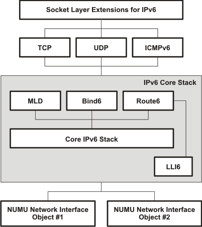

The IPv6 stack components and the RFCs it supports are as follows:

- IPv6 Core Stack
  - Neighbor Cache Support
  - Routing Table Support
  - Extension Header Support
  - Fragmentation/Reassembly
  - Binding Lifetime Management
  - Routing Table Lifetime Management
  - RFCs
- RFC 3596 DNS Extensions to Support IPv6
- RFC 2460 Internet Protocol Version 6 - Only support for processing of extension headers
- RFC 2461 Neighbor Discovery for IPv6
- RFC 2462 IPv6 Stateless Address Autoconfiguration
- RFC 2463 IPv6 Internet Control Message Protocol (ICMPv6) for IPv6
- RFC 2464 Transmission of IPv6 Packets over Ethernet Networks
- RFC 3484 Default Address Selection for IPv6 - Implemented partially
- RFC 3587 IPv6 Global Unicast Address Format
- RFC 3493 Basic Socket Interface Extensions for IPv6 - Implemented but not fully. No compatibility with IPv4 nodes and multicast.
- RFC 2373 IPv6 Addressing Architecture - No support for IPv6 addresses embedded with IPv4.
- Layer4 Support
  - ICMPv6
  - RAW
  - UDP
  - TCP
- Socket Layer Extensions for IPv6
- Application Support
  - TFTP
  - Telnet
  - Web Server
  - DNS

## G.2 Initialization and Deinitialization

To enable IPv6 in your application, users must take the following steps:

- Update your compiler options to define “_INCLUDE_IPv6_CODE”
- Update your linker options to link against the IPv6 versions of the NDK libraries instead of the IPv4 versions. For information on including these libraries see section 1.3.3 on the Library Directory Structure in the NDK User’s Guide
- Update the application code to initialize the IPv6 stack. See the example code listed after these steps for more information on this.
- Build your application.

The following example illustrates how the code to initialize the IPv6 stack can be done in the networkOpen function. Note the initialization does not have to be done here, but it serves as convenient place for this code:

```c
#define IPv6_DEVICE_INDEX 1


/*
 *  ======== IPv6DADStatus ========
 *  IPv6 initialization callback function
 */
static void IPv6DADStatus(IP6N Address, unsigned short dev_index, unsigned char Status)
{
    char strIPAddress[40];

    /* Convert the IP Address to String Format. */
    IPv6IPAddressToString(Address, strIPAddress);

    /* Print the status of the address. */
    printf("IPv6 address: %s on device %d is %s\n", strIPAddress, dev_index,
        (Status == 1) ? "UNIQUE" : "DUPLICATE");

    return;
}


/*
 *  ======== networkOpen ========
 *  User defined function (hook) that's typically passed as an argument to the
 *  NC_NetStart() API. Here, it's used to initialize the IPv6 stack.
 */
static void networkOpen()
{
    int status = 0;


#ifdef _INCLUDE_IPv6_CODE
    /* Initialize IPv6 */
    llEnter ();
    /*
     * IPv6_DEVICE_INDEX should be set to the interface ID of the interface to
     * initialize IPv6 on. For most users this value should be set to 1. Also
     * note that this value should always be 1 or greater.
     *
     * IPv6DADStatus is a function callback that is called when the IPv6 DAD
     * (Duplicate address detection) process has completed on an address.
     */
    status = IPv6InterfaceInit(IPv6_DEVICE_INDEX, IPv6DADStatus);
    llExit ();

    if (status < 0) {
        /* Unable to initialize the IPv6 stack */
    }
    else {
        /* IPv6 stack has been initialized */
    }
#endif
}
```

Deinitialization follows a similar pattern. The following example uses the NetworkClose function to illustrate this:

```c
/*
 *  ======== networkClose ========
 *  User defined function (hook) that's typically passed as an argument to the
 *  NC_NetStart() API. Here, it's used to deinitialize the IPv6 stack.
 */
static void networkClose()
{
    int status = 0;

#ifdef _INCLUDE_IPv6_CODE
    /* Enter the kernel Mode. */
    llEnter ();
    status = IPv6InterfaceDeInit(IPv6_DEVICE_INDEX);
    llExit ();

    /* Were we able to deinitialize the stack? */
    if (status < 0) {
        /* unable to deinitialize the IPv6 stack */
    }
    else {
        /* IPv6 stack deinitialized */
    }
#endif
}
```

## G.3 API Functions and Data Structures

### G.3.1 Socket Support for IPv6

The following is a list of Socket API that is supported:

- socket
- bind
- listen
- connect
- getpeername
- getsockname
- send
- sendto
- recv
- recvfrom
- setsockopt (limited IPv6 options supported)
- getsockopt (limited IPv6 options supported)
- close
- shutdown

The No-Copy variants for receive are not supported for IPv6 sockets.

In order for IPv6 sockets code to work correctly, application code must be compiled with _INCLUDE_IPv6_CODE defined and with IPv6 enabled in XGCONF.

### G.3.2 Architecture

Figure G-2 illustrates the internal architecture block diagram for the socket layer:

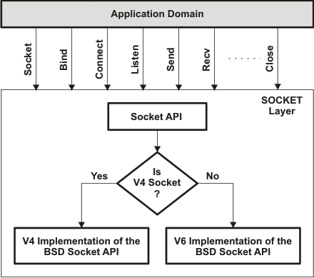

When a socket is created, it is marked as either an IPv4 socket or an IPv6 socket, i.e., in the socket creation the socket family selected is either AF_INET (IPv4) or AF_INET6 (IPv6). This is then used as a de-multiplexing field to differentiate which socket implementation needs to be selected. This architecture reduces the impact on the existing IPv4 implementation of sockets.

### G.3.3 Socket Options

The IPv6 socket layer supports all the standard socket properties except the following:

- SO_IFDEVICE The option binds the socket to an interface and ensures that packets are transmitted on the specified interface.
- SO_TXTIMESTAMP This is a Texas Instruments specific option that was used for time stamping the path through the IPv6 Stack.

Of all the IPv6 specific options, the only one supported is the IPV6_UNICAST_HOPS, which allows the configuration of the Hop Limit in the packet.

### G.3.4 Daemon6

NDK supports a module called *Daemon*, which is a single network task that monitors the socket status of multiple network servers. When activity is detected, the daemon creates a task thread specifically to handle the new activity. This is more efficient than having multiple servers, each with their own listening thread.

Since the Daemon operates on sockets, a new module called Daemon6 has been created that does the same functionality as Daemon except that it operates on V6 sockets.

The following snippet of code indicates how Echo Servers on UDP can be made to operate on both IPV4 and IPV6

```c
hEchoUdp = DaemonNew( SOCK_DGRAM, 0, 7, dtask_udp_echo, OS_TASKPRINORM,
                      OS_TASKSTKNORM, 0, 1 );

#ifdef _INCLUDE_IPv6_CODE
hEchoUdp6 = Daemon6New (SOCK_DGRAM, IPV6_UNSPECIFIED_ADDRESS, 7,
                        dtask_udp_echo6, OS_TASKPRINORM,
                        OS_TASKSTKNORM, 0, 1);
#endif
```

### G.3.5 Nettools Applications

The Net-Tools module in the NDK stack has multiple applications that are provided to System developers. These applications provide basic services such as Telnet, TFTP etc. This section documents the modifications in these applications to support IPv6.

#### G.3.5.1 Telnet

Telnet is implemented as a server daemon that resides on port 23 and waits for incoming connections. The Telnet protocol by itself is agnostic to the Layer3 implementation i.e. IPv4 or IPv6. To be able to support IPv6 the following code needs to be added in the application startup code:

```c
hTelnet6 = Daemon6New (SOCK_STREAM, IPV6_UNSPECIFIED_ADDRESS, 23,
                              (int(*)(SOCKET,uint32_t))telnetClientProcess,
                              OS_TASKPRINORM, OS_TASKSTKLOW,
                              (uint32_t)ConsoleOpen, 2);
```

The code uses the Daemon6 API described above and starts the Telnet Daemon that opens an IPv6 socket on port 23. There is no conflict since the IPv4 Telnet daemon has also opened port 23 since the socket library for IPv4 and IPv6 are different.

With these modifications the Telnet daemon works over IPv6. There is one minor change in the Telnet code base that needs to be addressed. This is a display issue; after performing the telnet the server displays the Peer IP Address and Port Information.

For example, on IPv4 the display is as follows:

```html
TCP/IP Stack Example Client
Welcome connection : 192.168.1.2:3881


Welcome to the console program.
Enter '?' or 'help' for a list of commands.
>
```

On IPv6, the display code needs to be modified as follows to display the IPv6 address of the peer:

```html
TCP/IP Stack Example Client
Welcome connection : fe80::a00:9ff:fedc:fbdc:1061


Welcome to the console program.
Enter '?' or 'help' for a list of commands.
>
```

#### G.3.5.2 TFTP

The TFTP is an IPv6 client that implements the Trivial File Transfer Protocol over IPv6. The TFTP protocol uses the IP Address and Port information to ensure that data packets being received match the peer server and port information; this is typically implemented by most TFTP implementations for a more secure file transfer.

To achieve modularity, a new module TFTP6 has been created, which was based on the TFTP module. Modifications have been done to ensure that the TFTP6 module uses the AF_INET6 family for socket creation and the security checks are done with respect to the IPv6 addresses.

The following new API has been published to be able to retrieve a file over an IPv6 network through TFTP:

```c
int Nt6TftpRecv (IP6N TftpIP, char *szFileName, char *FileBuffer,
                        uint32_t *FileSize, uint16_t *pErrorCode );
```

### G.3.5.3 DNS Client

The existent DNS Client in NDK is capable of doing IPv4 forward and reverse name resolutions [2]. This is extended to do IPv6 forward and reverse AAAA (Quad-A) type DNS lookups as described in RFC 3596 [2] over IPv4 network. There is no support for the DNS client to communicate with an IPv6 DNS server; i.e., the DNS client is only capable of doing name resolutions by communicating with an IPv4 DNS server.

To support IPv6 name resolution, the following changes have been made to the existing implementation of DNS:

- A new Record type T_AAAA specific to the Internet class has been defined that can store a single IPv6 address. The IANA assigned value of the type is 28 (decimal) [2].
- The basic HOSTENT data structure has been modified (as shown below) such that it can hold both IPv4 and IPv6 addresses.

```c
/**
 * @brief
 * The structure describes the Host Name - IP Address record
 *
 * @details
 * The HOSTENT structure holds information such as IPv4/v6
 * address, host name mappings for a given host. It is used
 * by the DNS resolver in conveying such HostName - IP Address
 * mappings to a user application.
 */
struct _hostent {
    /**
     * @brief    This is the official name / Fully Qualified Domain Name
     * (FQDN) of the host.
     */
    char *h_name;

    /**
     * @brief    This indicates the address family of the IP address that
     * maps to the given hostname. The values it takes are AF_INET (v4) /
     * AF_INET6 (v6).
     */
    int h_addrtype;

    /**
     * @brief    This indicates the length (in bytes) of the IP address that follows.
     * For IPv4 address it is set to 4, and for IPv6 address set to 16 bytes.
     */
    int h_length;

    /**
     * @brief    This is the number of IP addresses returned for the given
     * hostname.
     */
    int h_addrcnt;

#ifndef _INCLUDE_IPv6_CODE

    /**
     * @brief    List of up to MAXIPADDR IPv4 addresses (Network format) that map
     * to the given hostname.
     */
    uint32_t h_addr[MAXIPADDR];

#else
    /**
     * @brief    List of up to MAXIPADDR IPv4/IPv6 addresses that map to given hostname.
     */
    char* h_addr_list[MAXIPADDR];
#endif
}
```

> **NOTE:** The field *h_addr_list* is an array of strings that holds the IPv4/v6 addresses as pointers to IPN/IP6N, respectively. The following is an example illustration of how one could use the h_addr_list field to access IPv4/IPv6 address from the HOSTENT structure.

**IPv4 Illustration:**

```c
uint32_t IPTmp;
retcode = DNSGetHostByXXX( arg1, ... argn );

for( retcode = 0; retcode < phe->h_addrcnt; retcode++ )
{
    IPTmp = (uint32_t)RdNet32(phe->h_addr_list[retcode]);
    ConPrintf("IPAddr = ");
    ConPrintIPN(IPTmp);
    ConPrintf("\n");
}
```

**IPv6 Illustration:**

```c
IP6N IPv6Tmp;
retcode = DNSGetHostByXXX( arg1, ... argn );

for( retcode = 0; retcode < phe->h_addrcnt; retcode++ )
{
    IPv6Tmp = *(IP6N *)phe->h_addr_list[retcode];
    ConPrintf("IPv6 Addr = ");
    ConIPv6DisplayIPAddress(IPv6Tmp);
    ConPrintf("\n");
}
```

- Two new APIs have been added for hostname to IPv6 address and IPv6 address to hostname resolution. The following are the two new APIs:

**IPv6 Address to Hostname Resolution API (reverse DNS lookup for IPv6):**

```c
/**
 * @b Description
 * @n
 *      This function does reverse DNS lookup on the supplied
 *      IPv6 Address. On a successful return, pScrapBuf can be
 *      treated as a HOSTENT structure. The size of the scrap
 *      buffer (size) must be greater than the size of the structure
 *      as the structure will contain pointers into the scrap
 *      buffer, and the scrap buffer is also used for temporary
 *      name storage. 512 bytes of scrap buffer memory should be
 *      sufficient for most requests.
 *
 * @param[in] IPAddr
 *      The IPv6 address that needs to be resolved in IP6N format.
 *
 * @param[out] pScrapBuf
 *      Scrap buffer area to hold the results on a successful
 *      DNS resolution.
 *
 * @param[in] size
 *      Size of the scrap buffer available.
 *
 * @retval
 *      Success - 0
 *
 * @retval
 *      Error - >0, error code to determine the error.
 */
int DNSGetHostByAddr2(IP6N IPAddr, void *pScrapBuf, int size);
```

**Hostname to IPv6 Address Resolution API (forward DNS lookup for IPv6):**

```c
/**
 * @b Description
 * @n
 *      This function does DNS lookup on the supplied hostname.
 *      On a successful return, the pScrapBuf can be treated as a
 *      HOSTENT structure. The size of the scrap buffer (size)
 *      must be greater than the size of the structure as the
 *      structure will contain pointers into the scrap buffer, and
 *      the scrap buffer is also used for temporary name storage.
 *      512 bytes should be sufficient for most DNS requests.
 *
 *      If the host name "Name" is terminated with a dot ('.'), the
 *      dot is removed. If the name contains a dot anywhere, it is
 *      used unmodified for an initial lookup. If the lookup fails -
 *      the appropriate DNS error code is returned. No default
 *      domain lookups are performed for IPv6, so if the hostname
 *      provided by user does not contain a dot, implying no
 *      domain name is provided, this function returns a format error.
 *
 * @param[in] Name
 *      The hostname to be resolved supplied by the user.
 *
 * @param[in] af_family
 *      The family (AF_INET/AF_INET6) of the IP address to which the
 *      query needs to be resolved to. If AF_INET is provided as the
 *      argument, then DNSGetHostByName is called in turn for IPv4
 *      lookup.
 *
 * @param[out] pScrapBuf
 *      Scrap buffer area to hold the results on a successful
 *      DNS resolution.
 *
 * @param[in] size
 *      Size of the scrap buffer available.
 *
 * @retval
 *      Success - 0
 *
 * @retval
 *      Error - >0, error code to determine the error.
 */
int DNSGetHostByName2(char *Name, unsigned char af_family, void *pScrapBuf, int size);
```

### G.3.6 Configuring the IPv6 Stack

One of the key differences between IPv6 and IPv4 is that the IPv6 stack needs to be instantiated at run time. This is because all IPv6 enabled interfaces automatically get a link local address, which is identified by the unique MAC address. Once an IPv6 address is assigned, it is mandatory that the IPv6 stack perform the Duplicate Address Detection process to ensure address uniqueness.

This implies that unlike IPv4 addresses cannot be assigned to the interface before the Ethernet Link is up because this will imply that the DAD packets never get transmitted out hence defeating the overall purpose.

RFC 2462, Section 5.3, states the following:

A node forms a link-local address whenever an interface becomes enabled. An interface may become enabled after any of the following events:

- The interface is initialized at system startup time.
- The interface is reinitialized after a temporary interface failure or after being temporarily disabled by system management.
- The interface attaches to a link for the first time.
- The interface becomes enabled by system management after having been administratively disabled.

In order to support IPv6 all Platform Support Packages should be modified such that the above mentioned API’s are added in the Ethernet Link Change code. This is outside the context of the document and should be addressed in the NDK Support Package documentation.

Initialization and de-Initialization of the IPv6 stack is the responsibility of the system application and should be used in conjunction with the Link change events described above. Figure G-3 showcases the various entities in the system:

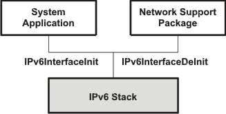

The IPv6 stack provides the necessary APIs, which are responsible for the initialization and cleanup of the IPv6 stack instance on the interface.

For user convenience, a sample command prompt demonstration has been provided with the IPv6 stack to initialize and attach the IPv6 stack to a desired interface, and to demonstrate the use of various IPv6 utilities. For more details, see the IPv6 Stack Testing section of the *TI Network Developer’s Kit (NDK) v2.21 User’s Guide* (SPRU523) document.

# Related Documentation From Texas Instruments

Additional information about the NDK can be found in the NDK Users Guide. If you have questions, you can ask them on the forum for your target device in TI’s E2E community.

If you have questions, you can ask them on the forum for the SDK that contains your NDK in [TI’s E2E community](http://e2e.ti.com/).